# Using *herbivar* to Fit Neutral Models

Vincent Pan

December 14, 2022

# 1 Prerequisets

To follow this vignette and use the *herbivar* package, you’ll need to first use the `install_github()` function from the *devtools* package to install the latest version of *herbivar* from github. You can just run the code chunk below on your machine to install the package.

```r
if(suppressMessages(!require(herbivar))){
  if(!nzchar(system.file(package = "devtools"))){
    install.packages("devtools")
  }
  devtools::install_github("vsbpan/herbivar")
} else {
  message("Sweet! Herbivar is installed!")
}
```

[output not shown]

```
## Sweet! Herbivar is installed!
```

# 2 Introduction

The goal of this vignette is to introduce to the user on using the *herbivar* package to fit the neutral herbivory model (Pan et al. 2022) to empirical herbivory data and assess model fit. I also demonstrate some handy functions that can be used to characterize probability distributions and wrangle herbivory data more broadly.

# 3 Neutral model

# 4 Formulation

# 5 Supporting functions

```r
x <- ralloT(1000, lambda = 3)

allo_fit <- fit_allo_herb(x,
                          id = "This_is_a_test_model")
```

```
## Overwriting optimizer to Brent for one dimensional optimization
```

## 5.1 Fitting the neutral model

```r
# Generate some fake herbivory data
set.seed(1)
x <- ralloT(1000, mean.phi.T = 0.222)
allo_fit <- fit_allo_herb(x)
```

```
## Overwriting optimizer to Brent for one dimensional optimization
```

```r
allo_fit
```

```
## Fitted result on
## method = Brent
## n = 1000
##
##    loglik       AIC      AICc       BIC
##  383.7087 -765.4173 -765.4133 -760.5096
##
##    function    gradient convergence
##          NA          NA           0
##
## mean.phi.T    min.phi    max.phi          a
##     fitted      0.005          1      1.556
##
##            Estimate  Std. lower upper
## mean.phi.T    0.237 0.006 0.225  0.25
```

```r
class(allo_fit)
```

```
## [1] "allo_herb_fit" "list"
```

The returned object has the class `allo_herb_fit` and is currently supported by some S3 generic methods `coef()`, `logLik()`, `AIC()`, `AICc()`, `BIC()`, `predict()`, and `print()`.

# 6 Generic null models

## 6.1 Formulation

## 6.2 Supporting functions

## 6.3 Fitting the generic null models

# 7 Model assessment

In this section, I show how one can use the package to assess model fit. There are numerous ways to determine how well a probability distribution fit to data, but they can be loosely divided into two types: absolute and relative measures of model fit. Absolute measures of model fit compare a model to data using objective measures. They inform how closely a model approximate observed data. Conversely, relative measures of model fit compete a model against alternative null hypotheses, allowing for strong inference (Platt 1964). McGill (2003) and McGill et al. (2006) provided excellent discussion on this important distinction for inference. I will just briefly emphasize that the two measures of model fit achieve slightly different goals. If you are interested purely in approximation or prediction, examining absolute measures of fit is sufficient. However, if you are interested in testing hypotheses, you need to examine the relative fit of a candidate model against other null or alternative hypotheses. In general, there is some burden of proof in ecology when one asserts the truth of a hypothesis, and we often show evidence through hypothesis significance testing. Examining absolute measures of model fit is still important, but not sufficient, because all alternative hypotheses can fit the data well on absolute measures or generate identical predictions. Therefore, tests based on absolute measures of fit maybe unable to falsify any hypothesis.

## 7.1 Absolute measures of fit

```r
compare_dist(data.list = list("obs" = allo_fit$data,
                              "pred" = predict(allo_fit)),
             test = c("ks","kl","ad"))
```

```
## $ks
##       ks.D       ks.P
## 0.06700000 0.02246371
##
## $kl
##    kl.div
## 0.0022342
##
## $ad
##       ad     ad.P
## 3.563800 0.014263
```

```r
probe_distribution(ralloT(1000, lambda = 3),
                   probes = c("mean", "var", "Skew","median"))
```

```
##       mean        var       Skew     median
## 0.18660921 0.05867473 1.90338738 0.08608654
```

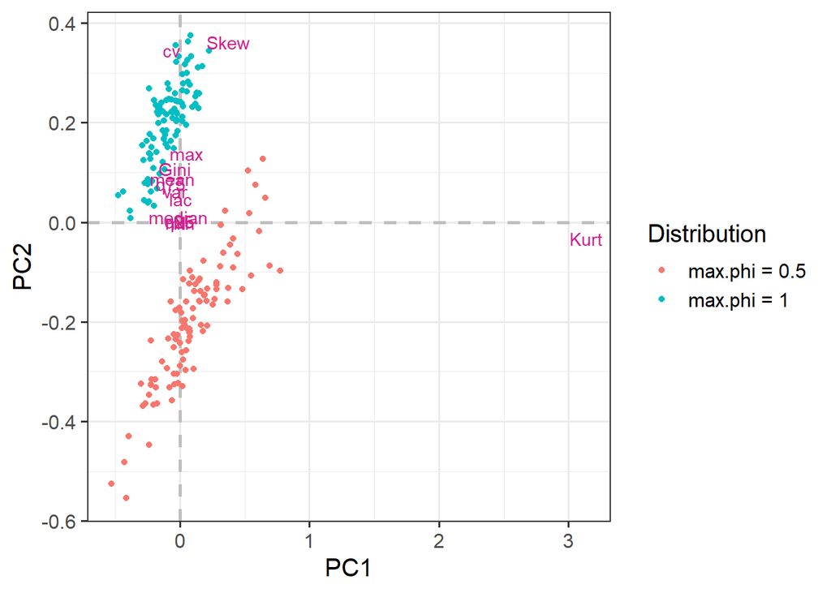

```r
allo_probed <- lapply(seq_len(100), function(i){
  x <- ralloT(1000, lambda = 3, max.phi = 1)
  probe_distribution(x)
}) %>%
  do.call("rbind",.)

allo_probed2 <- lapply(seq_len(100), function(i){
  x <- ralloT(1000, lambda = 3, max.phi = 0.5)
  probe_distribution(x)
}) %>%
  do.call("rbind",.)


probed.data <- rbind(
  data.frame("distribution" = "max.phi = 1", allo_probed),
  data.frame("distribution" = "max.phi = 0.5", allo_probed2)
)

vegan::rda(probed.data[,-1]) %>%
  get_biplot(choices = c(1,2),
             group = probed.data$distribution) +
  ggplot2::theme_bw(base_size = 15) +
  ggplot2::labs(color = "Distribution")
```

```r
vegan::rda(probed.data[,-1] ~ probed.data$distribution)
```

```
## Call: rda(formula = probed.data[, -1] ~ probed.data$distribution)
##
##               Inertia Proportion Rank
## Total          0.5383     1.0000
## Constrained    0.1006     0.1868    1
## Unconstrained  0.4377     0.8132   11
## Inertia is variance
##
## Eigenvalues for constrained axes:
##    RDA1
## 0.10058
##
## Eigenvalues for unconstrained axes:
##    PC1    PC2    PC3    PC4    PC5    PC6    PC7    PC8    PC9   PC10   PC11
## 0.4345 0.0018 0.0010 0.0002 0.0001 0.0001 0.0000 0.0000 0.0000 0.0000 0.0000
```

## 7.2 Relative measures of fit

```r
x <- ralloT(1000, lambda = 3)

allo_fit <- fit_allo_herb(x)
```

```
## Overwriting optimizer to Brent for one dimensional optimization
```

```r
htlnorm_fit <- fit_generic_null(x, family = "htlnorm")

LRT(htlnorm_fit,allo_fit)
```

```
##
##
--------- Models ---------
##               loglik df
## htlnorm_fit 421.2274  3
## allo_fit    459.5952  1
##
##
##
--------- Likelihood Ratio Test ---------
##     Chisq df P
##  -76.7356  2 1
```

# 8 Miscellaneous

## 8.1 Batch processing

When dealing with many data sets or many models fitted to many data sets, one may desire to perform one action across all data sets or all models. This is made easier by batch processing wrappers implemented in *herbivar*. To use these functions, in general, multiple data sets or multiple models of the same class should be stored in a named list. The list may be named by some identifier, such as the data set ID or survey ID.

```r
get_data_sim(list(allo_fit,
                  allo_fit,
                  allo_fit),
             n.sim = 3,
             return.obs = FALSE)
```

```
## $fitted.pred
## $fitted.pred[[1]]
## [1] 0.02 0.57 0.06
##
## $fitted.pred[[2]]
## [1] 0.07 0.89 0.03
##
## $fitted.pred[[3]]
## [1] 0.00 0.21 0.35
```

```r
get_dist_test_sim(list(allo_fit,
                       allo_fit,
                       allo_fit),
                  test = c("ks"),
                  nboot = 2) %>% suppressMessages()
```

[output not shown]

```
## , , 1
##
##       ks.D      ks.P
## [1,] 0.023 0.9540581
## [2,] 0.025 0.9134755
## [3,] 0.035 0.5726548
##
## , , 2
##
##       ks.D      ks.P
## [1,] 0.039 0.4324321
## [2,] 0.038 0.4657668
## [3,] 0.021 0.9801618
```

[figure not shown]

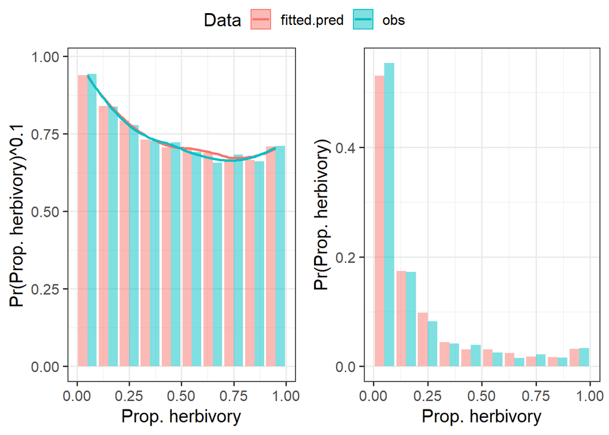

```r
plot_distributions(
  purrr::map(get_data_sim(list(allo_fit)), 1)
)
```

```r
apply_probes(
  list(x, x, x),
  add.id = FALSE,
  probes = c("mean", "Hoover", "J.index", "cd", "cv", "N","max","lac","Gini")
)
```

```
##        mean    Hoover   J.index        cd       cv    N max       lac      Gini
## 1 0.1868502 0.4753298 -3.646993 0.3185587 1.305714 1000   1 0.9419955 0.6173147
## 2 0.1868502 0.4753298 -3.646993 0.3185587 1.305714 1000   1 0.9419955 0.6173147
## 3 0.1868502 0.4753298 -3.646993 0.3185587 1.305714 1000   1 0.9419955 0.6173147
```

```r
set.seed(12)
bite_size_fit <- fit_bite_size(rallo(100, max.phi = 0.4),
                               min.phi = 0.005,
                               family = "all")
bite_size_fit
```

```
##           AICc dAICc df convergence
## allo_M -564.50  0.00  1           2
## allo_a -556.56  7.94  1           0
## allo   -555.15  9.35  0           0
## tlnorm -511.32 53.18  2           0
## kumar  -469.92 94.58  2           0
## cb     -468.81 95.69  2           0
## beta   -464.94 99.56  2           0
```

Currently, the following generic methods are supported: `coef()`, `print()`.

# 9 References